# spatial_modeling_HW

```r
library(nlme)
```

```r
library(vegan)
data(BCI)
BCI_xy = data.frame(x = rep(seq(625754, 626654, by=100), each=5),
                    y = rep(seq(1011569,  1011969, by=100), len=50))
```

1. Examine if there is evidence of spatial dependence in a rare and a common species in the BCI tree dataset

#to determine if a species is rare or common, look at how many individuals there are

```r
abu <- colSums(BCI)
quantile(abu)
```

```
##   0%  25%  50%  75% 100%
##    1    7   25   82 1717
```

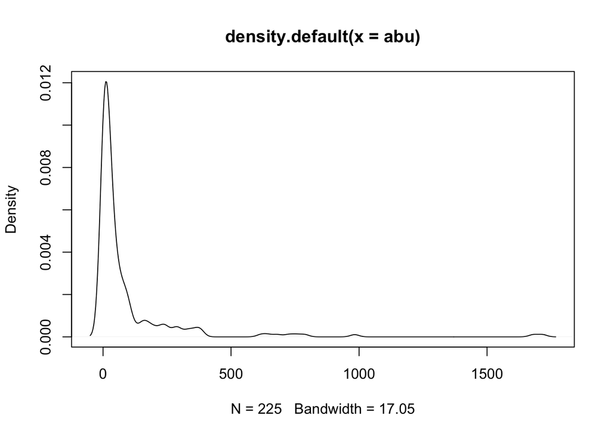

```r
plot(density(abu))
```

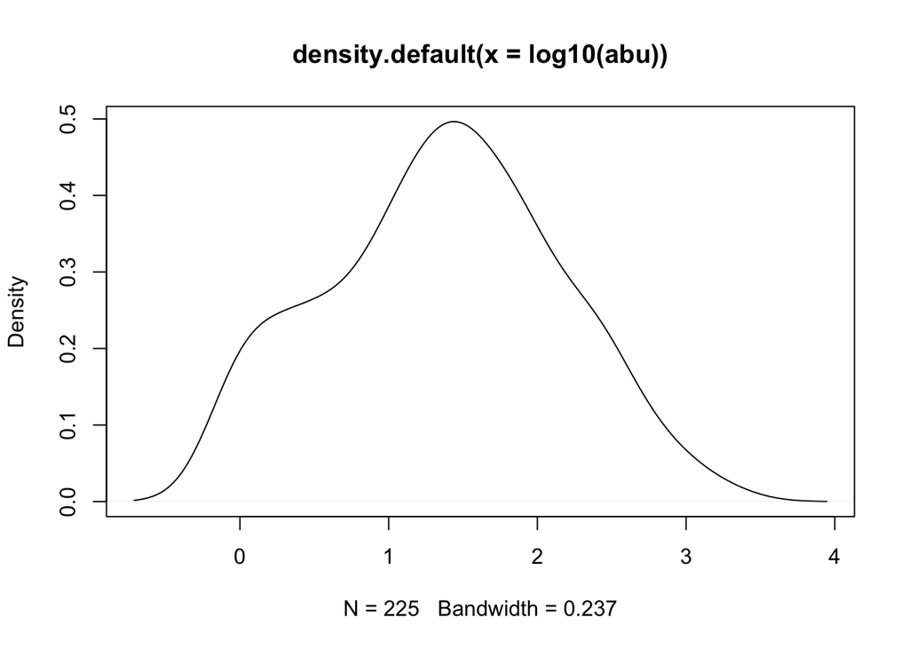

```r
plot(density(log10(abu)))
```

```r
which(abu > 25 & abu < 27)
```

```
## Erythrina.costaricensis          Inga.acuminata       Sterculia.apetala
##                      65                     100                     187
##   Symphonia.globulifera
##                     190
```

```r
which(abu > 82 & abu < 90 )
```

```
##  Cassipourea.guianensis Chrysophyllum.argenteum    Dendropanax.arboreus
##                      32                      44                      58
##      Guettarda.foliacea
##                      90
```

```r
rare_sp <- BCI[ ,100]
common_sp <- BCI[ , 44]
```

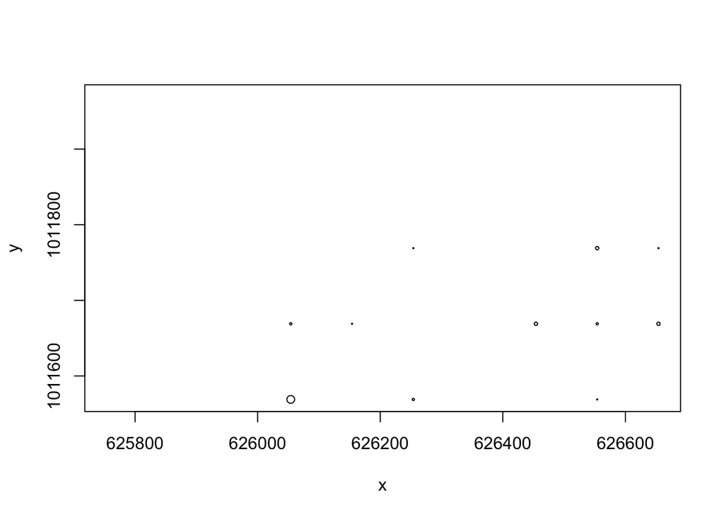

```r
plot(BCI_xy, cex = rare_sp / max(rare_sp)) # cex specifies scaling
```

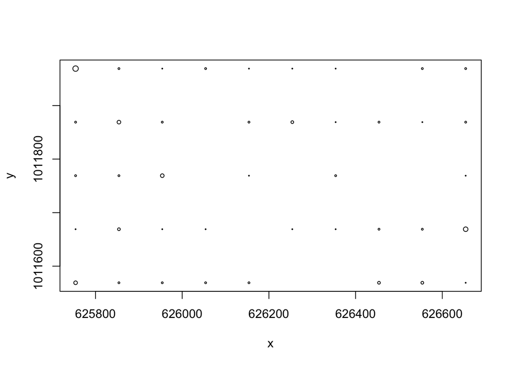

```r
plot(BCI_xy, cex = common_sp / max(common_sp))
```

# the rare species picked was Inga acuminata, the common species was Chrysophyllum argenteum

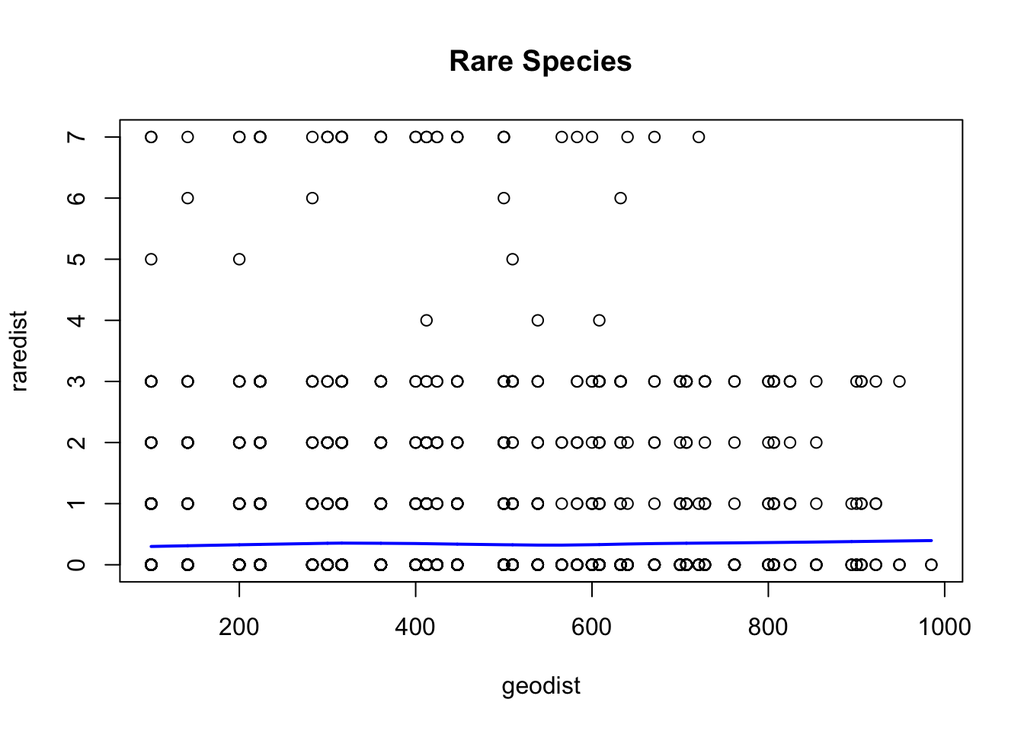

```r
geodist <- dist(BCI_xy)
raredist <- dist(rare_sp)
commdist <- dist(common_sp)
plot(geodist, raredist, main = "Rare Species")
lines(lowess(geodist, raredist), lwd = 2, col = "blue")
```

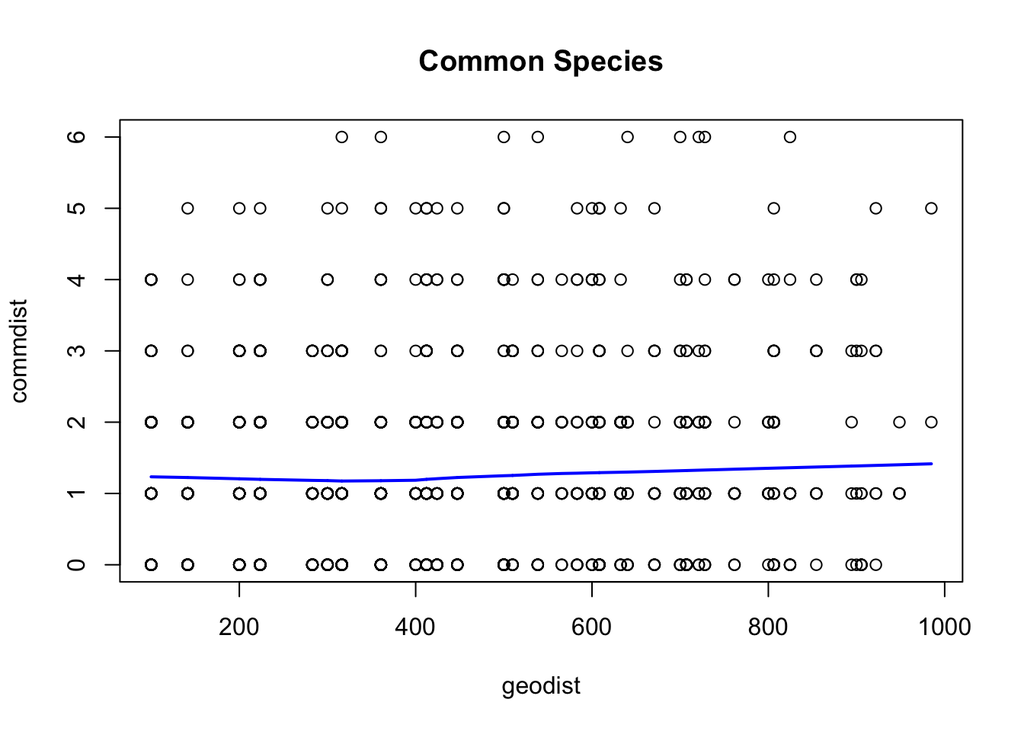

```r
plot(geodist, commdist, main = "Common Species")
lines(lowess(geodist, commdist), lwd = 2, col = "blue")
```

```r
mantel(geodist, commdist)
```

```
##
## Mantel statistic based on Pearson's product-moment correlation
##
## Call:
## mantel(xdis = geodist, ydis = commdist)
##
## Mantel statistic r: 0.09642
##       Significance: 0.043
##
## Upper quantiles of permutations (null model):
##    90%    95%  97.5%    99%
## 0.0745 0.0937 0.1103 0.1306
## Permutation: free
## Number of permutations: 999
```

```r
mantel(geodist, raredist)
```

```
##
## Mantel statistic based on Pearson's product-moment correlation
##
## Call:
## mantel(xdis = geodist, ydis = raredist)
##
## Mantel statistic r: 0.01753
##       Significance: 0.404
##
## Upper quantiles of permutations (null model):
##    90%    95%  97.5%    99%
## 0.0876 0.1162 0.1342 0.1617
## Permutation: free
## Number of permutations: 999
```

2. Build two generalized linear models to predict the abundance of the species Drypetes standleyi using the abundance of other tree species in the study site. Specifically examine the following species as predictor variables:

```r
sp_ids = c("Cordia.lasiocalyx", "Hirtella.triandra",
           "Picramnia.latifolia", "Quassia.amara",
           "Tabernaemontana.arborea", "Trattinnickia.aspera",
           "Xylopia.macrantha")
```

Note renaming the species ids to something a little easier to work with like “sp_a”, “sp_b” will make model construction a little less cumbersome

Model 1: only include a single species as a predictor variable

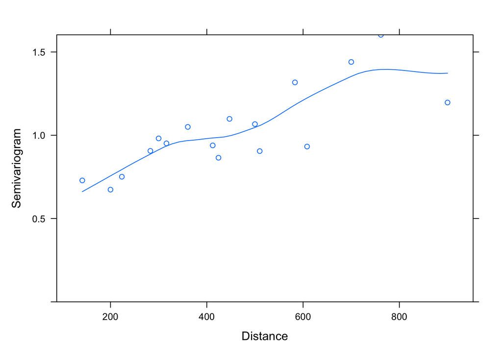

```r
sp_a <- BCI$Cordia.lasiocalyx
sp_b <- BCI$Hirtella.triandra
sp_c <- BCI$Picramnia.latifolia
sp_d <- BCI$Quassia.amara
sp_e <- BCI$Tabernaemontana.arborea
sp_f <- BCI$Trattinnickia.aspera
sp_g <- BCI$Xylopia.macrantha
sp_res <- BCI$Drypetes.standleyi

abu_lm <- gls(sp_res ~ sp_a, data = BCI_xy)
plot(Variogram(abu_lm, form= ~ x + y))
```

# the above appears to be not entirely independent.

Model 2: include all of the species as predictor variables

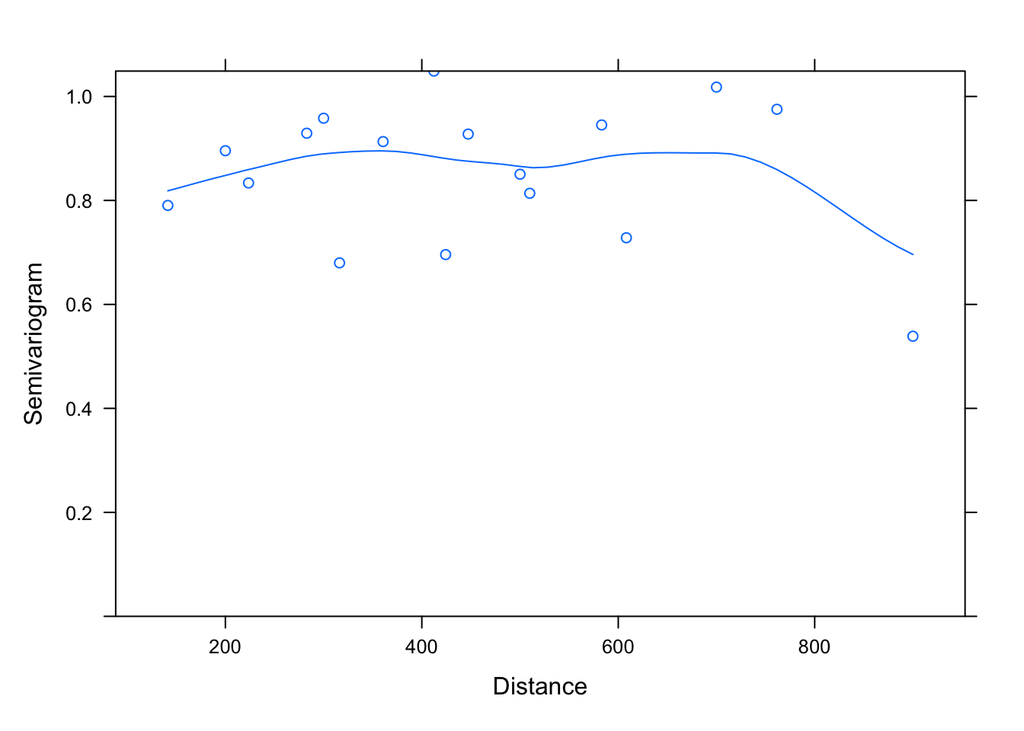

```r
abu_lm2 <- gls(sp_res ~ sp_a + sp_b + sp_c + sp_d + sp_e + sp_f + sp_g, data = BCI_xy)
plot(Variogram(abu_lm2, form= ~ x + y))
```

# the above seems to show that using more species increases the “independence”. This could show that certain species are very dependent, while others are independent,and when using all of them as the predictor variables we wash out the effect

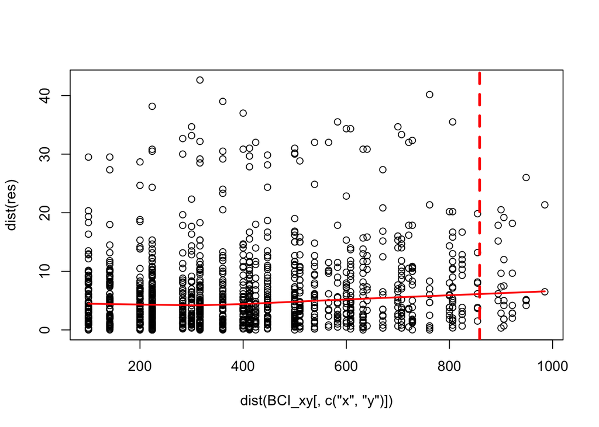

```r
max_abu <- max(abu) / 2

res = residuals(abu_lm)
plot(dist(BCI_xy[, c('x', 'y')]), dist(res))
lines(lowess(dist(BCI_xy[, c('x', 'y')]), dist(res)), col='red', lwd=2)
abline(v = max_abu, col='red', lwd=3, lty=2)
```

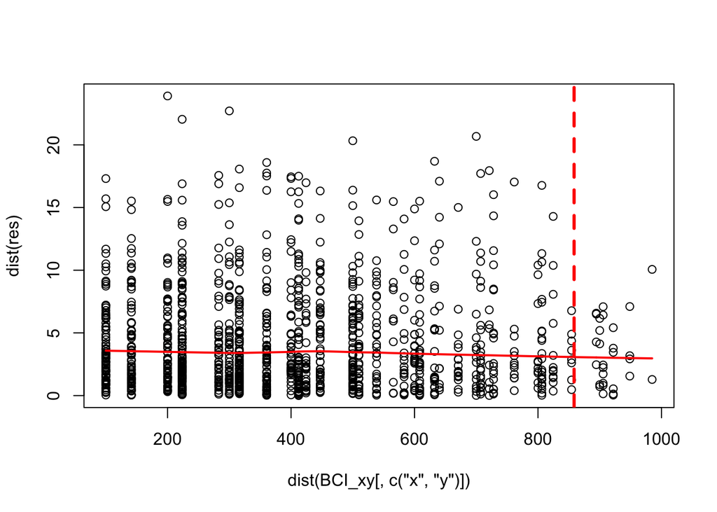

```r
max_abu <- max(abu) / 2

res = residuals(abu_lm2)
plot(dist(BCI_xy[, c('x', 'y')]), dist(res))
lines(lowess(dist(BCI_xy[, c('x', 'y')]), dist(res)), col='red', lwd=2)
abline(v = max_abu, col='red', lwd=3, lty=2)
```

# The above residuals shows spatial independence

With both models examine the spatial dependence of the residuals using the function Variogram. Model the spatial dependence in the residuals using one of the error structures available.

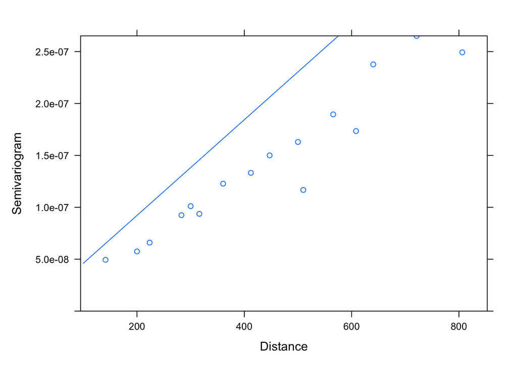

```r
abu_exp <- update(abu_lm, corr=corExp(form=~x + y))

plot(Variogram(abu_exp, maxDist = max_abu))
```

#the above is for the model using just a singular predictor species # the above error model doesn’t look right, this model does not fit this error

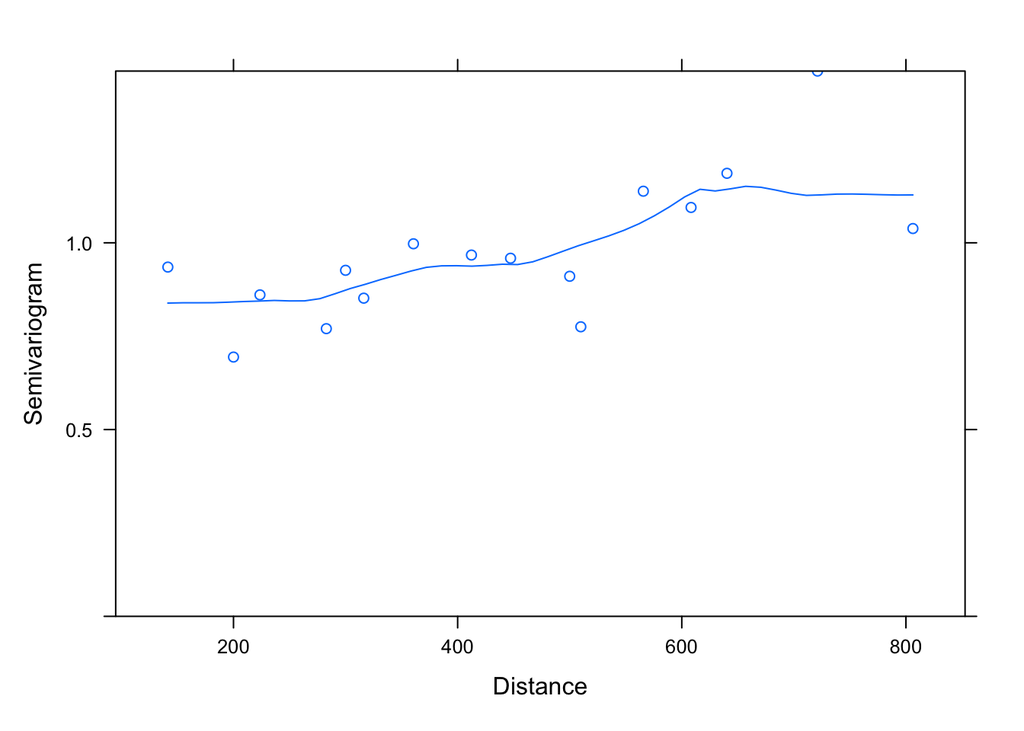

```r
plot(Variogram(abu_exp, resType='normalized', maxDist = max_abu))
```

#the above is for the model using just a singular predictor species #the above error looks much better as a mormalized model

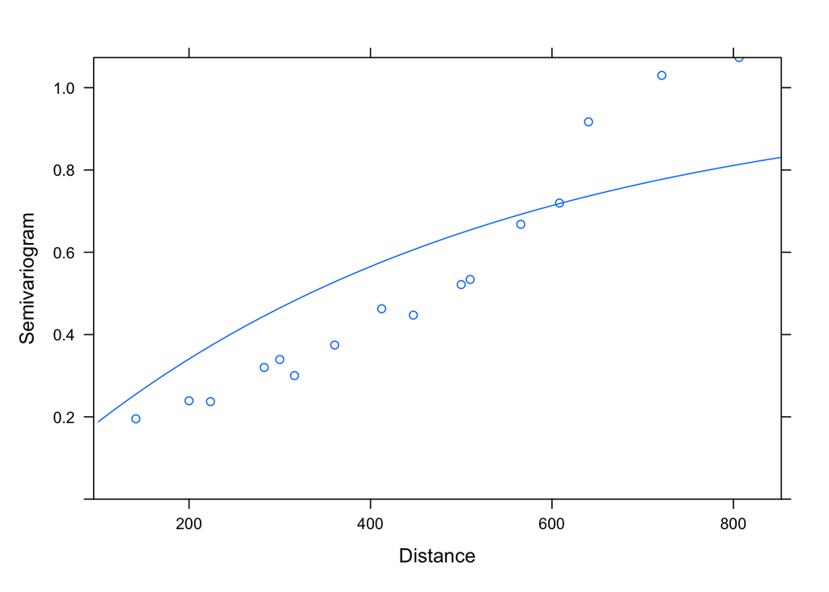

```r
abu_exp2 <- update(abu_lm2, corr=corExp(form=~x + y))

plot(Variogram(abu_exp2, maxDist = max_abu))
```

# the above is for the glm using all species as predictors

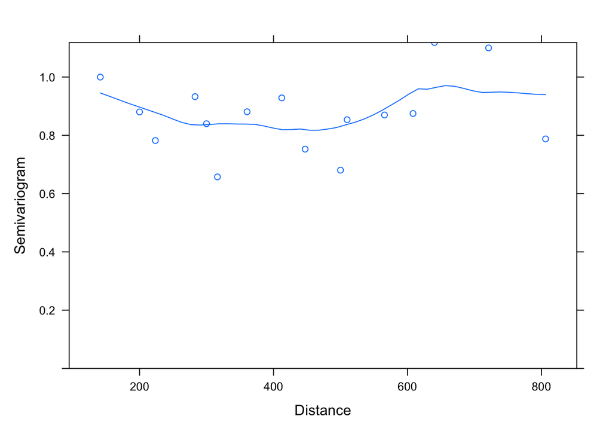

```r
plot(Variogram(abu_exp2, resType='normalized', maxDist = max_abu))
```

# the above is for the glm using all species as predictors #the above fits better than the exponential

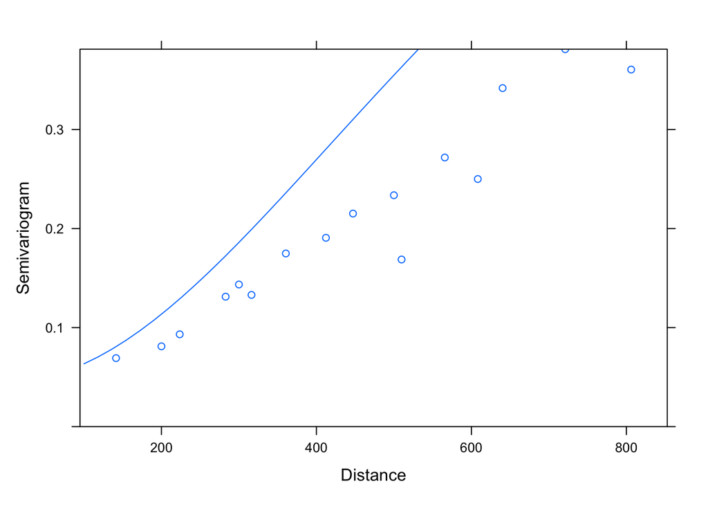

```r
abu_rat_nug <- update(abu_lm, corr=corRatio(form=~x + y, nugget=T))
# examine fit of error model to model residuals
plot(Variogram(abu_rat_nug, maxDist = max_abu))
```

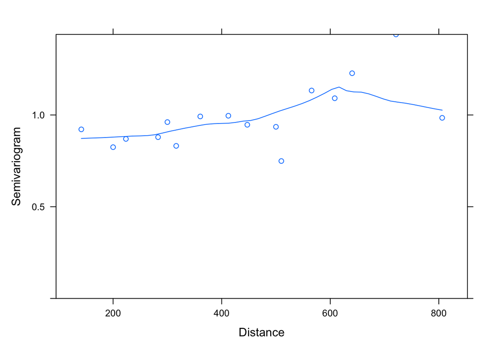

```r
plot(Variogram(abu_rat_nug, resType='n', maxDist = max_abu))
```

```r
# this is for the species comparison using one predictor
```

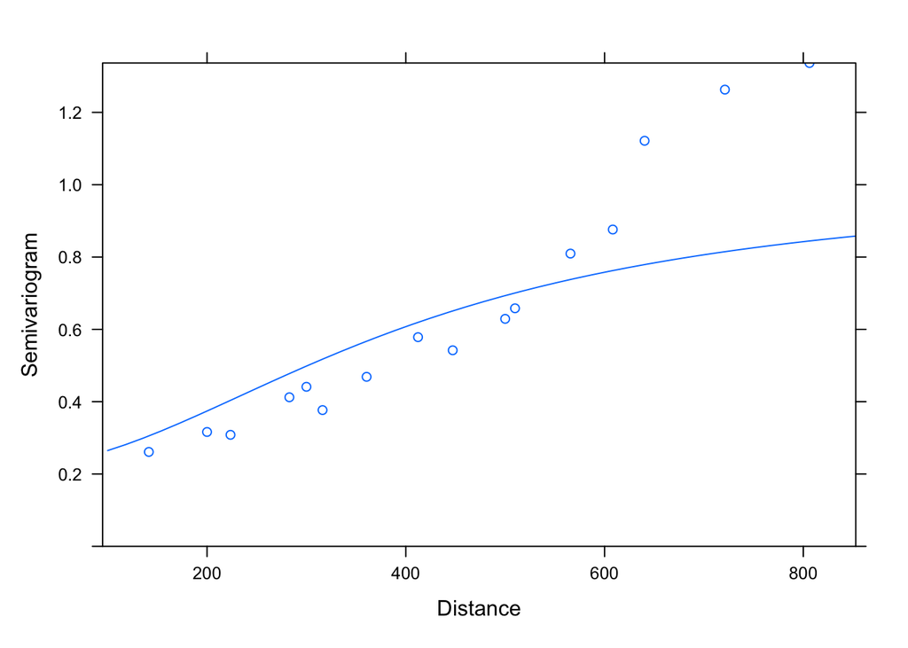

```r
abu_rat_nug2 <- update(abu_lm2, corr=corRatio(form=~x + y, nugget=T))
# examine fit of error model to model residuals
#this is for the species using all predictor variables
plot(Variogram(abu_rat_nug2, maxDist = max_abu))
```

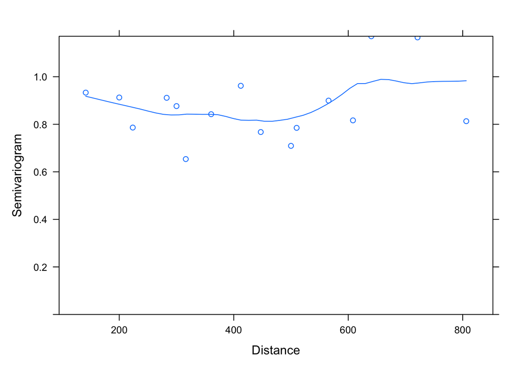

```r
plot(Variogram(abu_rat_nug2, resType='n', maxDist = max_abu))
```